# Titanic Passenger Survival Analysis

## Introduction

This study will analyse a dataset that contains demographic and passenger information from 891 passengers of the 2224 passengers and crew on board the Titanic and will investigate the following questions:

**What factors made passengers more likely to survive? Did travelling with family have any impact on survival?**

**Data sources**:

The data set used is available [here](https://d17h27t6h515a5.cloudfront.net/topher/2016/September/57e9a84c_titanic-data/titanic-data.csv) and a description of the dataset can be found on the [Kaggle](https://www.kaggle.com/c/titanic/data) website.

## Data Loading

All necessary packages and functions are imported and the csv dataset is loaded into a pandas dataframe.

```python
# import all necessary packages and functions.
import numpy as np
import pandas as pd
import seaborn as sns
import matplotlib.pyplot as plt
from itertools import groupby
from IPython.display import display

#set sns and plot global style
sns.set(style="white", palette="muted", color_codes=True)
%matplotlib inline

#global values
TOTAL_COUNT = 0
SURVIVED_COUNT = 1
SURVIVAL_RATE = 2
```

```python
#read passenger data into pandas dataframe
passenger_data = pd.read_csv('titanic-data.csv')

#show raw data
display(passenger_data.head())
```

|  | PassengerId | Survived | Pclass | Name | Sex | Age | SibSp | Parch | Ticket | Fare | Cabin | Embarked |
| --- | --- | --- | --- | --- | --- | --- | --- | --- | --- | --- | --- | --- |
| 0 | 1 | 0 | 3 | Braund, Mr. Owen Harris | male | 22.0 | 1 | 0 | A/5 21171 | 7.2500 | NaN | S |
| 1 | 2 | 1 | 1 | Cumings, Mrs. John Bradley (Florence Briggs Th... | female | 38.0 | 1 | 0 | PC 17599 | 71.2833 | C85 | C |
| 2 | 3 | 1 | 3 | Heikkinen, Miss. Laina | female | 26.0 | 0 | 0 | STON/O2. 3101282 | 7.9250 | NaN | S |
| 3 | 4 | 1 | 1 | Futrelle, Mrs. Jacques Heath (Lily May Peel) | female | 35.0 | 1 | 0 | 113803 | 53.1000 | C123 | S |
| 4 | 5 | 0 | 3 | Allen, Mr. William Henry | male | 35.0 | 0 | 0 | 373450 | 8.0500 | NaN | S |

### Data Dictionary

Here are data definitions taken from the [Kaggle](https://www.kaggle.com/c/titanic/data) website.

| Variable | Definition | Key |
| --- | --- | --- |
| survival | Survival | 0 = No, 1 = Yes |
| pclass | Ticket class | 1 = 1st, 2 = 2nd, 3 = 3rd |
| sex | Passenger gender |  |
| Age | Passenger age in years | Age is fractional if less than 1. If the age is estimated, is it in the form of xx.5 |
| sibsp | # of siblings / spouses aboard the Titanic | Sibling = brother, sister, stepbrother, stepsister; Spouse = husband, wife (mistresses and fiancés were ignored) |
| parch | # of parents / children aboard the Titanic | Parent = mother, father; Child = daughter, son, stepdaughter, stepson; Some children travelled only with a nanny, therefore parch=0 for them. |
| ticket | Ticket number | Not analysed because they are considered to be strongly related to Passenger Class. |
| fare | Passenger fare | Not analysed because they are considered to be strongly related to Passenger Class. |
| cabin | Cabin number | Not analysed, given that the emergency took place over many hours it is assumed everyone would be able to vacate cabins and have access to the boat decks. (Subject to caveats in the historical context… |
| embarked | Port of Embarkation | C = Cherbourg, Q = Queenstown, S = Southampton |

## Data Wrangling and Data Cleansing

### Missing Age Data

Some age values are missing. The approach I decided to take was to fill the missing values with zero and ignore these passengers when investigating the age distribution and other statistics. (Filling with mean values would have distorted this data analysis.)

When creating the adult dataset I chose to include passengers with missing age data within it. This action increased the count of adults significantly (601 -> 778) and consequently should improve the statistical observations. There is a risk that some may have been children but the class and gender will be valid. I considered the benefit of having the additional rows in the adult anlysis outweighed this risk.

### Other conversions

The set_passenger_class function is applied to the Pclass column to provide text values for class. The set_age_group function is applied to the Age column to provide text names for age ranges. These conversions make the following code intuitive and easier to understand.

Finally columns that are not used (name, ticket, fare and cabin) in the analysis are dropped from the dataframe, see data dictionary for details.

```python
#utility functions to clean dataset

def set_passenger_class(pclass):
    """
    Return a text description for the numeric passenger class parameter
    unknown is default if 1|2|3 is not provided
    """
    pclass_name= "unknown"
    if pclass == 1 : pclass_name = "first"
    if pclass == 2 : pclass_name = "second"
    if pclass == 3 : pclass_name = "third"
    return pclass_name

def set_age_group(age):
    """
    Return an age group name derived from age parameter
    unknown is default if zero age provided
    """
    age = float(age)
    age_group_name = 'unknown'
    if  0 <  age <=  1 : age_group_name = 'infant'
    if  2 <= age <=  9 : age_group_name = 'child'
    if 10 <= age <= 17 : age_group_name = 'adolescent'
    if 18 <= age       : age_group_name = 'adult'
    return age_group_name

def set_companions(value):
    """
    Return a text description for the numeric value parameter
    zero returns No otherwise Yes
    """
    companions= "no"
    if value > 0 : companions = "yes"
    return companions




# Age columns has some NaN values, set these to zero
passenger_data["Age"] = passenger_data["Age"].fillna(value=0 )

# Apply set_passenger_class function to Pclass column to provide text values for class
passenger_data["Pclass"] = passenger_data["Pclass"].apply(set_passenger_class)

# Apply set_age_group function to Age_with_mean column to provide text names for age ranges
passenger_data["AgeGroup"] = passenger_data["Age"].apply(set_age_group)

# Apply set_companions function to Siblings and Spouses column to provide Yes/No
passenger_data["SibSp"] = passenger_data["SibSp"].apply(set_companions)

# Apply set_companions function to Parents and Children column to provide Yes/No
passenger_data["Parch"] = passenger_data["Parch"].apply(set_companions)

# Drop columns that are not used in the analysis
passenger_data.drop('Name', axis=1, inplace=True)
passenger_data.drop('Ticket', axis=1, inplace=True)
passenger_data.drop('Fare', axis=1, inplace=True)
passenger_data.drop('Cabin', axis=1, inplace=True)


#show cleaned data
display(passenger_data.head())
```

|  | PassengerId | Survived | Pclass | Sex | Age | SibSp | Parch | Embarked | AgeGroup |
| --- | --- | --- | --- | --- | --- | --- | --- | --- | --- |
| 0 | 1 | 0 | third | male | 22.0 | yes | no | S | adult |
| 1 | 2 | 1 | first | female | 38.0 | yes | no | C | adult |
| 2 | 3 | 1 | third | female | 26.0 | no | no | S | adult |
| 3 | 4 | 1 | first | female | 35.0 | yes | no | S | adult |
| 4 | 5 | 0 | third | male | 35.0 | no | no | S | adult |

### Plotting and Utility Functions

These sections declare some plotting and utility functions used in later sections.

The plotting code has been adapted from code by others where credited.

```python
# main function to analyse passenger dataframes
def calculate_survival_rate(df):
    """
    Expects a dataframe containing passenger information.
    Returns three values in a tuple:
    The total passenger count contained in the dataframe.
    The count of passengers that have the Survived column flag set to 1
    The survival rate obtained by dividing the previous values.
    """
    passenger_count = df.PassengerId.count()
    survived_count  = df[(df['Survived'] == 1)].PassengerId.count()
    return passenger_count, survived_count, survived_count / float(passenger_count)

# pretty print function for calculate_survival_rate()
def display_survival(df):
    print("There are %d passengers in total; %d survived; survival rate: %f" % calculate_survival_rate(df))

def histogram_plot(df,title):
    fig = plt.figure(figsize=(8,6))
    sns.despine(left=True)

    # Plot a historgram
    sns.distplot(df,hist=True, kde=False)

    ax = fig.add_subplot(111)
    ax.set_ylabel('Frequency')
    plt.title(title)
    plt.tight_layout()
```

```python
# Adapted from udacity code in babs_visualizations.py in Bay Area Bike Share project
def categorical_plot(data, key = '',key_name = '' ):
    """
    Plot number of passengers, by variable.

    """
    # Create plotting figure
    plt.figure(figsize=(8,6))

    # Summarize dataframe to get counts in each group
    data['count'] = 1
    data = data.groupby(key, as_index = False).count()

    levels = data[key].unique()
    n_levels = len(levels)
    bar_width = 0.8

    for i in range(n_levels):
        trips_bar = plt.bar(i - bar_width/2, data.loc[i]['count'], width = bar_width)

    # add labels to ticks for each group of bars.
    plt.xticks(range(n_levels), levels)

    # Common attributes for plot formatting
    if key_name == ' ':
        key_name = ' '.join([x.capitalize() for x in key.split('_')])
    plt.xlabel(key_name)
    plt.ylabel("Number of Passengers")
    plt.title("Number of Passengers by {:s}".format(key_name))
    plt.show()
```

```python
#Multi index plotting code adapted from
#https://stackoverflow.com/questions/31845258/pandas-multi-index-plotting
def add_line(ax, xpos, ypos):
    line = plt.Line2D([xpos, xpos], [ypos + .1, ypos],
                      transform=ax.transAxes, color='gray')
    line.set_clip_on(False)
    ax.add_line(line)

def label_len(my_index,level):
    labels = my_index.get_level_values(level)
    return [(k, sum(1 for i in g)) for k,g in groupby(labels)]

def label_group_bar_table(ax, df):
    ypos = -.1
    scale = 1./df.index.size
    for level in range(df.index.nlevels)[::-1]:
        pos = 0
        for label, rpos in label_len(df.index,level):
            lxpos = (pos + .5 * rpos)*scale
            ax.text(lxpos, ypos, label, ha='center', transform=ax.transAxes)
            add_line(ax, pos*scale, ypos)
            pos += rpos
        add_line(ax, pos*scale , ypos)
        ypos -= .1

def multi_index_plot(values,index,plot_title = ''):
    data = pd.DataFrame(data={'val': values}, index=index)
    # unstack last level to plot two separate columns
    data = data.unstack(level=-1)
    ax = data['val'].plot(kind='bar')
    #Below 2 lines remove default labels
    ax.set_xticklabels('')
    ax.set_xlabel('')
    plt.title(plot_title)
    label_group_bar_table(ax, data)
```

## Isolate and Evaluate Dataset Variables

Let's start our analysis by looking at the individual variables that are contained within the dataset in isolation and assess their potential impact on the analysis.

### Passenger Age

Let's generate and describe a dataset that contains the age data for passengers whose age is greater than zero.

```python
#create passenger age dataset
passenger_age = passenger_data[(passenger_data["Age"] > 0 )]["Age"]

passenger_age.describe()
```

```
count    714.000000
mean      29.699118
std       14.526497
min        0.420000
25%       20.125000
50%       28.000000
75%       38.000000
max       80.000000
Name: Age, dtype: float64
```

```python
# Compute IQR
Q1 = passenger_age.quantile(0.25)
Q3 = passenger_age.quantile(0.75)
IQR = Q3 - Q1

print IQR
```

```
17.875
```

```python
#compute outlier boundaries
outlier_lower_boundary = Q1 - (1.5 * IQR)
outlier_upper_boundary = Q3 + (1.5 * IQR)

print outlier_lower_boundary
print outlier_upper_boundary
```

```
-6.6875
64.8125
```

From the 714 passengers who have an age value, the mean is 30 years old and the IQR is 18 years (20-38 years old).

There are no lower outliers because the boundary is below zero, but passengers aged 65 and above are considered statistical outliers.

Let's look at the distribution of ages in this dataset.

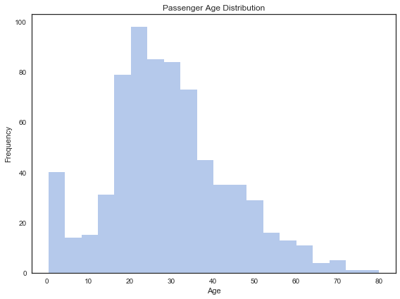

```python
#Plot age histogram

histogram_plot(passenger_age,'Passenger Age Distribution')
```

The distribution is pretty much as expected given the mean and IQR. It has a slight positive skew and has a frequency spike at 0-2 years old. Otherwise the distribution is fairly normal.

### Passenger Age Group

In the data cleansing process the numeric age column was used to create an age group indicator. We can see the distribution in this bar chart.

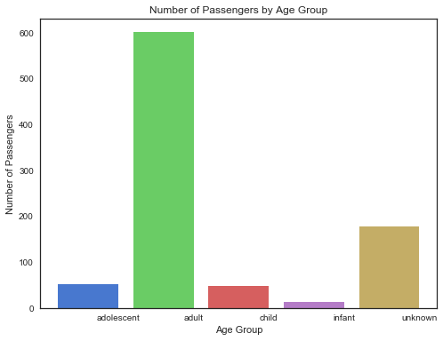

```python
# show plot of passengers by age group
categorical_plot(passenger_data, 'AgeGroup','Age Group')
```

We can see that the majority of passengers are adults over 17 years old. The values for infant, child and adolescent are small and risk being meaningless when analysed; to address this I am going to aggregate them all into one child group.

Passengers of unknown age had their age set to zero in the data cleansing phase and are included as adults in our dataset.

```python
#create adult only dataset
adult_data = passenger_data[(passenger_data['AgeGroup'] == "adult")
                             | (passenger_data['AgeGroup'] == "unknown") ]

#create child only dataset
child_data = passenger_data[((passenger_data['AgeGroup'] == "infant")
                               | (passenger_data['AgeGroup'] == "child")
                               | (passenger_data['AgeGroup'] == "adolescent"))]
```

Let's also look at the total and survived child/adult passenger counts using these datasets.

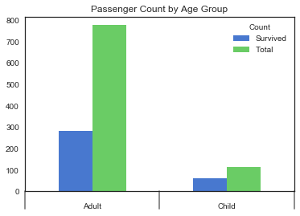

```python
#Create groupings for multilevel index
gender = ('Adult', 'Child')
survived = ('Total','Survived')
index = pd.MultiIndex.from_product([gender, survived], names=['Class','Count'])

#list to hold datapoints
passenger_count = []

#populate list with adult set total count and survived count
result = calculate_survival_rate(adult_data)
passenger_count.append(result[TOTAL_COUNT])
passenger_count.append(result[SURVIVED_COUNT])

#populate list with child set total count and survived count
result = calculate_survival_rate(child_data)
passenger_count.append(result[TOTAL_COUNT])
passenger_count.append(result[SURVIVED_COUNT])

#convert datapoints to NumPy array
values=np.array(passenger_count)

#plot data
multi_index_plot(values,index,'Passenger Count by Age Group')
```

From this we can easily see that the child survival rate is significantly higher than the adult rate. We should also consider that the majority of passengers are adults and that, children, who cannot be relied upon to act independently, may be subject to extraneous factors not captured in the dataset.

Consequently some of the more detailed multi-variable comparisons below will apply only to adults.

### Passenger Gender

Let's look at the total and survived passenger counts by gender.

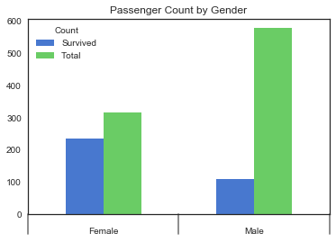

```python
#Create groupings for multilevel index
gender = ('Female', 'Male')
survived = ('Total','Survived')
index = pd.MultiIndex.from_product([gender, survived], names=['Class','Count'])

#list to hold datapoints
passenger_count = []

#populate list by iterating through gender appending total count and survived count
for gender in ["female","male"]:
            result = calculate_survival_rate(passenger_data[(passenger_data['Sex'] == gender)])
            passenger_count.append(result[TOTAL_COUNT])
            passenger_count.append(result[SURVIVED_COUNT])

#convert datapoints to NumPy array
values=np.array(passenger_count)

#plot data
multi_index_plot(values,index,'Passenger Count by Gender')
```

From this we can see that the male/female ratio is about 2:1 and that the female survival rate is significantly better. This imbalance, combined with the difference in survival rate will skew any analysis that does not distinguish between passenger genders.

### Passenger Class

Passenger class is a proxy for socio-economic status. Let's look at the total and survived passenger counts by passenger class.

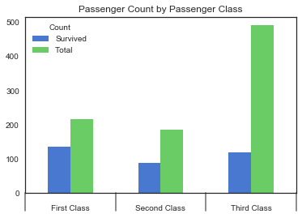

```python
#Create groupings for multilevel index
pclass = ('First Class', 'Second Class','Third Class')
survived = ('Total','Survived')
index = pd.MultiIndex.from_product([pclass, survived], names=['Class','Count'])

#list to hold datapoints
passenger_count = []

#populate list by iterating through class types appending total count and survived count
for pclass in ["first","second","third"]:
            result = calculate_survival_rate(passenger_data[(passenger_data['Pclass'] == pclass)])
            passenger_count.append(result[TOTAL_COUNT])
            passenger_count.append(result[SURVIVED_COUNT])

#convert datapoints to NumPy array
values=np.array(passenger_count)

#plot data
multi_index_plot(values,index,'Passenger Count by Passenger Class')
```

Here we see that third class passengers significantly outnumber first and second. We can also see that the survival rates fall as we move accross first second and third class.

### Embarked Port

Let's look at the total and survived passenger counts by the port in which the passengers embarked.

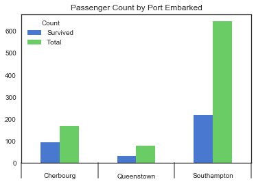

```python
#Create groupings for multilevel index
embarked = ('Cherbourg','Queenstown','Southampton')
survived = ('Total','Survived')
index = pd.MultiIndex.from_product([embarked, survived], names=['Embarked','Count'])

#list to hold datapoints
passenger_count = []

#populate list by iterating through class types appending total count and survived count
for embarked in ["C","Q","S"]:
            result = calculate_survival_rate(passenger_data[(passenger_data['Embarked'] == embarked)])
            passenger_count.append(result[TOTAL_COUNT])
            passenger_count.append(result[SURVIVED_COUNT])

#convert datapoints to NumPy array
values=np.array(passenger_count)

#plot data
multi_index_plot(values,index,'Passenger Count by Port Embarked')
```

This only tells us that the majority of our passengers boarded at Southampton. This variable is not expected to impact survival rates in itself and so will not be considered further.

## Multi-Variable Analysis and Explorations

Let's look at the overall passenger counts grouping the different variables considered above together.

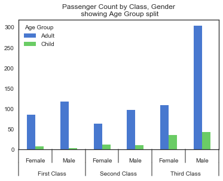

```python
#Create groupings for multilevel index
pclass = ('First Class', 'Second Class','Third Class')
gender = ('Male', 'Female')
age_group = ('Child', 'Adult')
index = pd.MultiIndex.from_product([pclass, gender, age_group], names=['Class', 'Gender', 'Age Group'])

#list to hold datapoints
passenger_count = []

#populate list by iterating through class and gender appending total count for both child and adult sets
for pclass in ["first","second","third"]:
    for gender in ["male","female"]:
            result = calculate_survival_rate(child_data[(child_data['Pclass'] == pclass) & (child_data['Sex'] == gender)])
            passenger_count.append(result[TOTAL_COUNT] )
            result = calculate_survival_rate(adult_data[(adult_data['Pclass'] == pclass) & (adult_data['Sex'] == gender)])
            passenger_count.append(result[TOTAL_COUNT] )

#convert datapoints to NumPy array
values=np.array(passenger_count)

#plot data
multi_index_plot(values,index,'Passenger Count by Class, Gender\n showing Age Group split')
```

There are no real surprises here; the passenger counts by class, gender and age group are all consistent with the conclusions from the individual variable examinations.

### Survival Rates

Let's look at the survival rates using the same groupings.

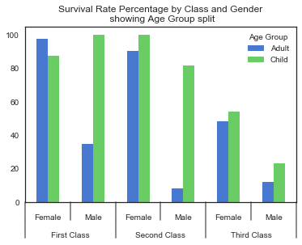

```python
#Create groupings for multilevel index
pclass = ('First Class', 'Second Class','Third Class')
gender = ('Male', 'Female')
age_group = ('Child', 'Adult')
index = pd.MultiIndex.from_product([pclass, gender, age_group], names=['Class', 'Gender', 'Age Group'])

#list to hold datapoints
survival_rates = []

#populate list by iterating through class and gender appending survival rate percentage for both child and adult sets
for pclass in ["first","second","third"]:
    for gender in ["male","female"]:
            result = calculate_survival_rate(child_data[(child_data['Pclass'] == pclass) & (child_data['Sex'] == gender)])
            survival_rates.append(result[SURVIVAL_RATE] * 100)
            result = calculate_survival_rate(adult_data[(adult_data['Pclass'] == pclass) & (adult_data['Sex'] == gender)])
            survival_rates.append(result[SURVIVAL_RATE] * 100)

#convert datapoints to NumPy array
values=np.array(survival_rates)

#plot data
multi_index_plot(values,index,'Survival Rate Percentage by Class and Gender\n showing Age Group split')
```

Looking at the survival rates it's clear that the adage women and children first applies. The survival rates for first and second class women and children are high and corresponding adult male survival rates are low especially in second class. Survival rates for third class passengers are lower but women and children still do better than men.

Let's look at adult survival in detail by standardising the survival rates to explore statistical significance.

```python
#list to hold index
index=[]

#list to hold datapoints
rate =[]

#populate list by iterating through class and gender appending survival rate for the adult set
for gender in ["female","male"]:
    for pclass in ["first","second","third"]:
        index.append(gender + "-" + pclass)
        result = calculate_survival_rate(adult_data[(adult_data['Sex'] == gender) & (adult_data['Pclass'] ==pclass)])
        rate.append(result[SURVIVAL_RATE])

#convert datapoints and index to dataframe
df = pd.DataFrame({'survival rate' : pd.Series(rate, index)} )

#calculate standard deviation from mean for survival rate
df['sdfm'] =  ((df - df.mean()) / df.std(ddof=0))['survival rate']

display(df)
```

|  | survival rate | sdfm |
| --- | --- | --- |
| female-first | 0.976744 | 1.402508 |
| female-second | 0.906250 | 1.200707 |
| female-third | 0.486239 | -0.001643 |
| male-first | 0.347458 | -0.398926 |
| male-second | 0.082474 | -1.157483 |
| male-third | 0.121711 | -1.045163 |

Survival rates for both first (+1.4) and second class (+1.2) adult females are more than a standard deviation above mean. Second class adult males (-1.16) are more than a standard deviation below mean and third class males are a standard deviation below mean (-1.0).

In a normal distribution we would expect to find 68% of the population within +/- one standard deviation from mean. This distribution only has two of the six population groups falling in this range containing 27% of the adult population.

**So, we can conclude that the high survival rates for first and second class women and the high mortality rates for second and third class men are statistically significant.**

## The Impact of Siblings and Spouses

The dataset defines family relations in this way: Sibling = brother, sister, stepbrother, stepsister; Spouse = husband, wife (mistresses and fiancés were ignored).

Let's first look at the survival rates for adults across our groupings identifying passengers that were alone or accompanied according to our definition of SibSp.

We will then calculate the deltas of the survival rates between alone and accompanied and look for statistical significance.

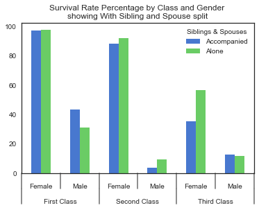

```python
#Create groupings for multilevel index
pclass = ('First Class', 'Second Class','Third Class')
gender = ('Male', 'Female')
accompanied = ('Accompanied', 'Alone')
index = pd.MultiIndex.from_product([pclass, gender, accompanied], names=['Class', 'Gender', 'Siblings & Spouses'])

#list to hold datapoints
survival_rates = []

#populate list by iterating through class and gender sibsp values appending survival rate percentage for adult set
for pclass in ["first","second","third"]:
    for gender in ["male","female"]:
           for sibsp in ["yes","no"]:
                result = calculate_survival_rate(adult_data[(adult_data['Pclass'] == pclass)
                                                         & (adult_data['Sex'] == gender)
                                                         & (adult_data['SibSp'] == sibsp)])
                survival_rates.append(result[SURVIVAL_RATE] * 100)


#convert datapoints to NumPy array
values=np.array(survival_rates)

#plot data
data = multi_index_plot(values,index,'Survival Rate Percentage by Class and Gender \nshowing With Sibling and Spouse split')
```

```python
#list to hold index
index=[]

#list to hold datapoints
rate =[]

#populate list by iterating through class and gender sibsp values appending the delta survival rate for adult set
for gender in ["female","male"]:
    for pclass in ["first","second","third"]:
        index.append(gender + "-" + pclass)
        #value with SibSp
        result1 = calculate_survival_rate(adult_data[(adult_data['Pclass'] == pclass)
                                                         & (adult_data['Sex'] == gender)
                                                         & (adult_data['SibSp'] == 'yes')])
        #value without SibSp
        result2 = calculate_survival_rate(adult_data[(adult_data['Pclass'] == pclass)
                                                         & (adult_data['Sex'] == gender)
                                                         & (adult_data['SibSp'] == 'no')])
        #calculate delta
        rate.append(result2[SURVIVAL_RATE] - result1[SURVIVAL_RATE])

#convert datapoints and index to dataframe
df = pd.DataFrame({'delta rate' : pd.Series(rate, index)} )

#calculate standard deviation from mean for delta rate
df['sdfm'] =  ((df - df.mean()) / df.std(ddof=0))['delta rate']

display(df)
```

|  | delta rate | sdfm |
| --- | --- | --- |
| female-first | 0.002168 | -0.272921 |
| female-second | 0.036437 | 0.072930 |
| female-third | 0.210021 | 1.824766 |
| male-first | -0.123547 | -1.541650 |
| male-second | 0.057222 | 0.282695 |
| male-third | -0.007037 | -0.365819 |

If the delta is positive then passengers traveling alone had a higher survival rate. Conversely a negative delta indicates traveling with siblings or spouses increased the survival rate.

Two groups are statistically significant: first class males and third class females, both being more than a standard deviation from mean. First class males are 1.5 standard deviations below mean and third class females 1.8 standard deviations above mean.

**So, we can conclude that the higher survival rates for accompanied first class men and for third class women traveling alone are statistically significant.**

## The Impact of Parents Accompanying Children

The dataset defines family relations in this way: Parent = mother, father; Child = daughter, son, stepdaughter, stepson; some children travelled only with a nanny, therefore parch=0 for them.

Let's first look at the survival rates for adults across our groupings identifying passengers that were alone or accompanied according to our definition of Parch. As we are only looking at adult passengers this will be assumed to be adult parents traveling with children.

We will then calculate the deltas of the survival rates between alone and accompanied and look for statistical significance.

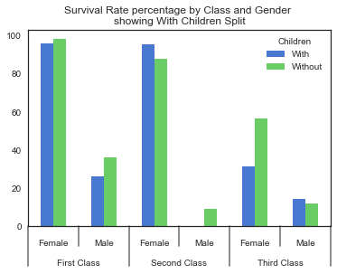

```python
#Create groupings for multilevel index
pclass = ('First Class', 'Second Class','Third Class')
gender = ('Male', 'Female')
accompanied = ('With', 'Without')
index = pd.MultiIndex.from_product([pclass, gender, accompanied], names=['Class', 'Gender', 'Children'])

#list to hold datapoints
survival_rates = []

#populate list by iterating through class and gender parch values appending survival rate percentage for adult set
for pclass in ["first","second","third"]:
    for gender in ["male","female"]:
           for parch in ["yes","no"]:
                result = calculate_survival_rate(adult_data[(adult_data['Pclass'] == pclass)
                                                         & (adult_data['Sex'] == gender)
                                                         & (adult_data['Parch'] == parch)])
                survival_rates.append(result[SURVIVAL_RATE] * 100)

#convert datapoints to NumPy array
values=np.array(survival_rates)

#plot data
multi_index_plot(values,index,'Survival Rate percentage by Class and Gender \nshowing With Children Split')
```

```python
#list to hold index
index=[]

#list to hold datapoints
rate =[]

#populate list by iterating through class and gender sibsp values appending the delta survival rate for adult set
for gender in ["female","male"]:
    for pclass in ["first","second","third"]:
        index.append(gender + "-" + pclass)
        #value with Parch
        result1 = calculate_survival_rate(adult_data[(adult_data['Pclass'] == pclass)
                                                         & (adult_data['Sex'] == gender)
                                                         & (adult_data['Parch'] == 'yes')])
        #value without Parch
        result2 = calculate_survival_rate(adult_data[(adult_data['Pclass'] == pclass)
                                                         & (adult_data['Sex'] == gender)
                                                         & (adult_data['Parch'] == 'no')])
        #calculate delta
        rate.append(result2[SURVIVAL_RATE] - result1[SURVIVAL_RATE])

#convert datapoints and index to dataframe
df = pd.DataFrame({'delta rate' : pd.Series(rate, index)} )

#calculate standard deviation from mean for delta rate
df['sdfm'] =  ((df - df.mean()) / df.std(ddof=0))['delta rate']

display(df)
```

|  | delta rate | sdfm |
| --- | --- | --- |
| female-first | 0.023607 | -0.367668 |
| female-second | -0.073593 | -1.294411 |
| female-third | 0.253282 | 1.822155 |
| male-first | 0.100478 | 0.365262 |
| male-second | 0.091954 | 0.283986 |
| male-third | -0.022716 | -0.809325 |

If the delta is positive then passengers traveling without children had a higher survival rate. Conversely a negative delta indicates traveling with children increased the survival rate.

Two groups are statistically significant: second class and third class females, both being more than a standard deviation from mean. Second class females are 1.3 standard deviations below mean and third class females 1.8 standard deviations above mean.

**So, we can conclude that the higher survival rates for second class women with children and for third class women without children are statistically significant.**

# Conclusions

### What were the primary factors made passengers more likely to survive?

From our investigations certain combinations of factors: passenger class, gender and age had a clear impact.

All third class passengers have relatively poor survival rates regardless of age and gender, probably as a consequence of poor evacuation management decisions:

> [...] an organized call for third-class passengers to proceed to the boat deck was not made until about fifty minutes after the collision. There was no realization that, given the deficiency of lifeboats, this was fatal to the chances of most third-class passengers. (Davenport-Hines, p.281)

Female passengers and children (both male and female) in first and second class have high survival rates. Correspondingly male passengers in first and second class have low survival rates (very low in the case of second class). By examining the standard deviations from mean for these adult survival rates we have concluded that these observations are statistically significant.

There are some secondary factors related to travelling with family, that influenced survival rates. My analysis showed that higher survival rates for the following groups are statistically significant:

- first class men accompanied by siblings and spouses and third class women travelling alone
- third class women without children and second class women with children

**It could be argued that the results of the investigation simply confirm the cultural convention of 'women and children first' combined with poor evacuation management decisions made in a crisis situation.**

### Investigation Limitations and Constraints

The analysis was performed using the entire sample of 891 passenger records and summarises their survival outcomes. We would expect to find similar survival outcomes for the rest of the passengers but because of the partitioning of the passenger population by age group, class and gender some groups have relatively low population numbers from which it may be unwise to extrapolate.

While this analysis is interesting in an historical and social perspective, it is not possible, due to the changes in maritime safety practice, to use this data to predict passenger survival for a modern day maritime disaster. It might be possible and interesting to compare analysis with [contemporary events](https://en.wikipedia.org/wiki/List_of_maritime_disasters_in_the_20th_century).

**Historical Context**

We are only able to consider the information available to us in the dataset, however, the time after the collision was very chaotic and it is likely that there were many extraneous factors in play that are not captured in the dataset.

Historical records provide us with some insight into what these might be.

We have assumed that all passenger classes had free access to the boat deck during the evacuation but in normal circumstances the passenger classes were segregated:

> US immigration laws stipulated that passengers of different classes must be separated on liners by locked metal barriers to limit their supposed power to spread contagion, (Davenport-Hines,p.9)

During the evacuation it seems likely that the gates were opened but without a clear and well signed exit route, free access cannot be completely assumed:

> The emergency door from third-class into second-class was opened early on. There was a route from there up the centre of the liner, past the second-class smoking room, straight to the boat deck. [...] some third-classers were baffled by the maze of corridors, and excluded by the locked gates that US immigration laws required between third-class decks and other parts of the ship, though these were unlocked by 12.30. (Davenport-Hines, p.281)

Another extraneous factor could be the reluctance of passengers and crew to use the lifeboats after the incident with P&O’s Oceana:

> The recent capsizing in the English Channel of a lifeboat from P&O’s Oceana, which drowned nine people, discouraged passengers from being jerked down the tall precipitous side of a liner which was not expected to sink. They anticipated a delay in reaching New York, but nothing worse, and were reluctant to leave the warm comforts of the liner for the chill perils of a frail craft bobbing on the ocean. The P&O fatalities inhibited White Star’s officers, too, from filling their lifeboats. (Davenport-Hines, p.279)

References:

- Davenport-Hines, Richard. Titanic Lives: Migrants and Millionaires, Conmen and Crew. HarperCollins Publishers.
- https://stackoverflow.com/questions/31845258/pandas-multi-index-plotting
- https://pandas.pydata.org/pandas-docs/stable/
- https://docs.scipy.org/doc/numpy/
- https://seaborn.pydata.org/generated/seaborn.distplot.html